# AlphaGenome motif-importance analysis

## 6.2 SVN leading motif logos

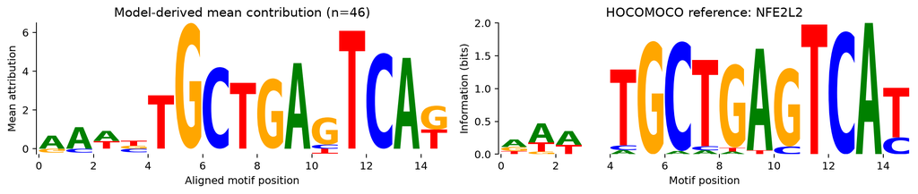

NFE2L2 (positive); 46 tested sites, 32 important regions

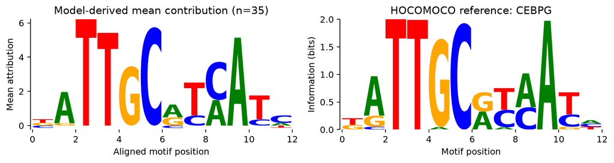

CEBPG (positive); 35 tested sites, 26 important regions

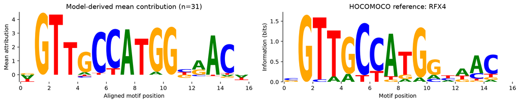

RFX4 (positive); 31 tested sites, 23 important regions

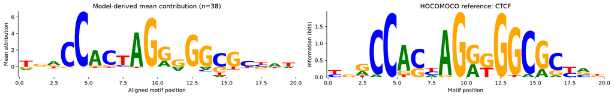

CTCF (positive); 38 tested sites, 21 important regions

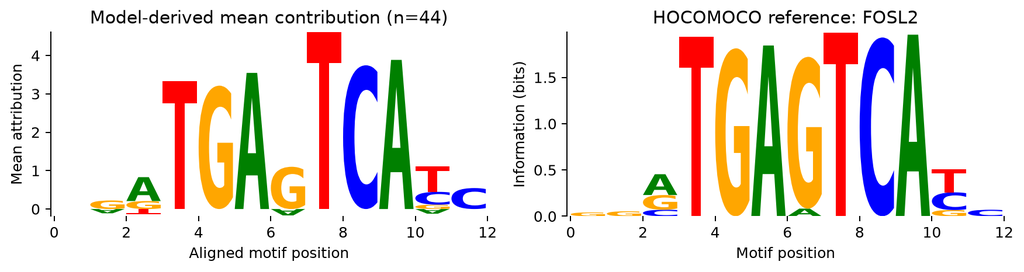

FOSL2 (positive); 44 tested sites, 18 important regions

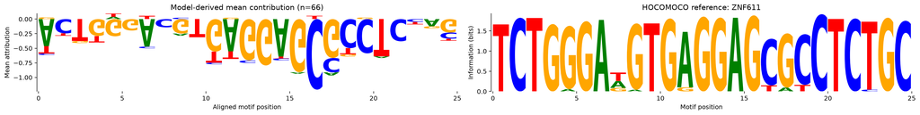

ZNF611 (negative); 66 tested sites, 8 important regions

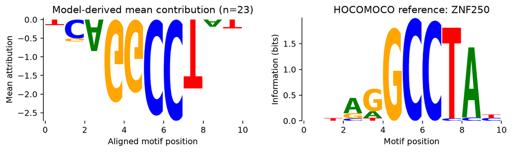

ZNF250 (negative); 23 tested sites, 4 important regions

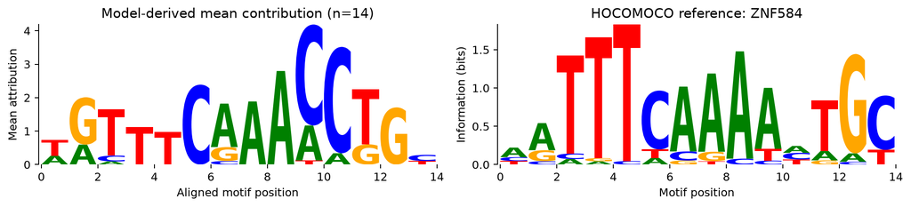

ZNF584 (positive); 14 tested sites, 1 important regions

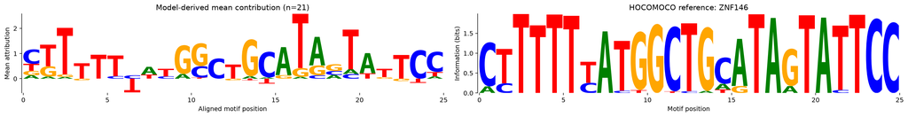

ZNF146 (positive); 21 tested sites, 1 important regions

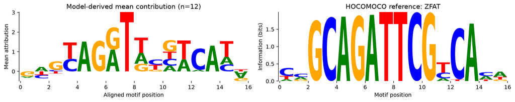

ZFAT (positive); 12 tested sites, 0 important regions

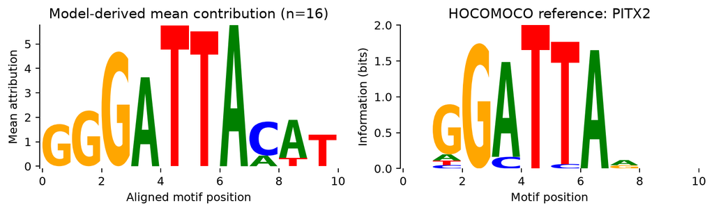

PITX2 (positive); 16 tested sites, 0 important regions

## 6.3 EVS leading motif logos

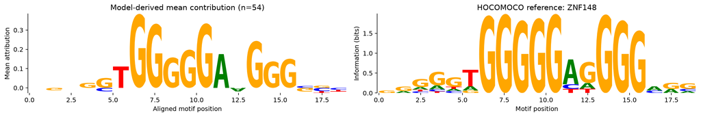

ZNF148 (positive); 54 tested sites, 28 important regions

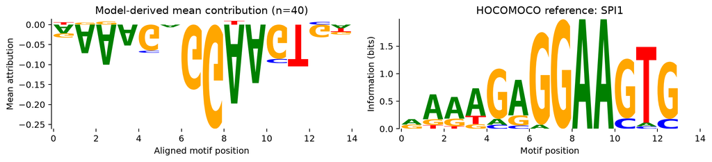

SPI1 (negative); 40 tested sites, 11 important regions

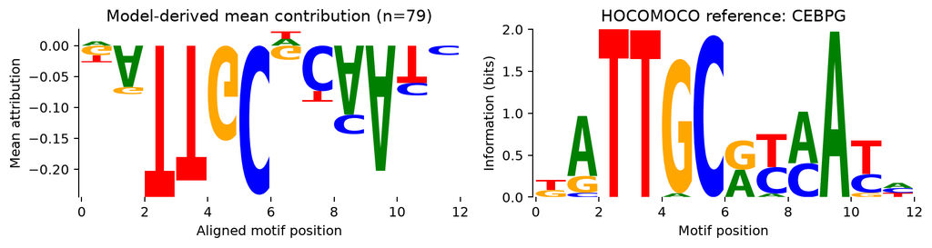

CEBPG (negative); 79 tested sites, 11 important regions

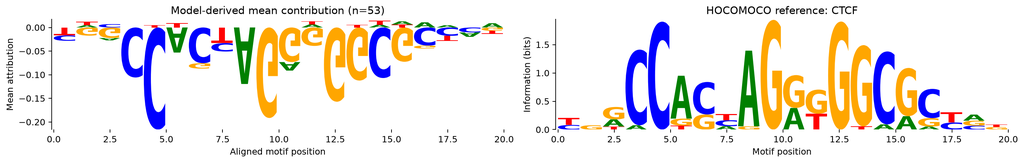

CTCF (negative); 53 tested sites, 11 important regions

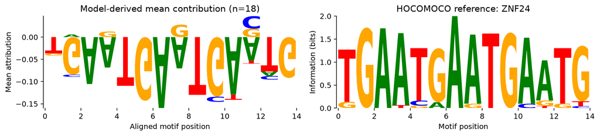

ZNF24 (negative); 18 tested sites, 7 important regions

# 7 Descriptive comparison across tasks

The models were trained for different classification problems and are explained on their native held-out data. The comparison below is therefore descriptive: it highlights recurring motif clusters, while effect magnitudes should not be treated as directly calibrated between models.

The bars summarize only the selected ablation panel, not every seqlet called across the test set. When a task contains both positive- and negative-attribution occurrences of the same motif, the plot retains the sign with more significant regions (then more sampled sites as a tie-breaker) so that each task contributes at most one bar per motif.

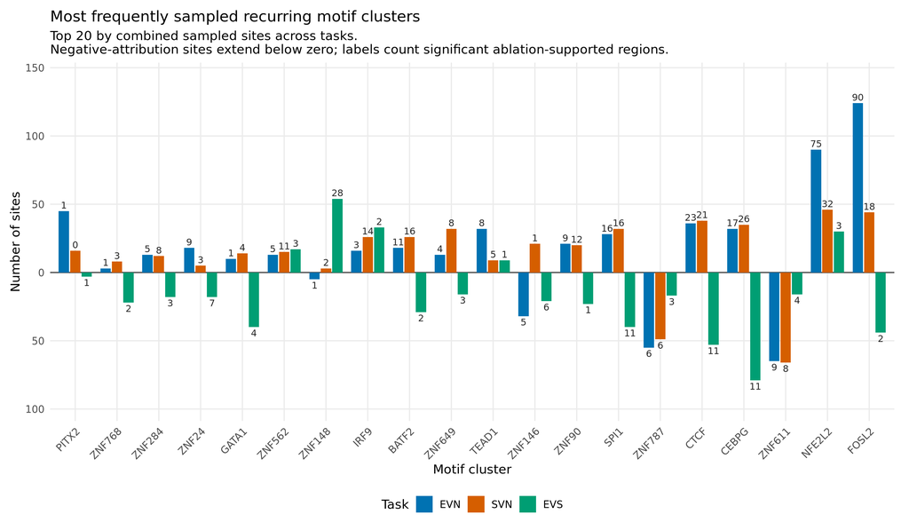

# 8 Class-enriched motif clusters

Class enrichment is calculated only within the balanced, selected candidate panel. It is not a genome-wide motif-enrichment test and is kept separate from the causal ablation result.

Class-enriched clusters within the selected panel

| Motif | Sign | Sites | Important regions | Positive-class sequences | Negative-class sequences | Adjusted enrichment p-value | Mean ablation effect |
| --- | --- | --- | --- | --- | --- | --- | --- |
| EVN |  |  |  |  |  |  |  |
| PITX2 | positive | 45 | 1 | 1 | 43 | 1.85 × 10<sup>−11</sup> | 1.27 |
| NFE2L2 | positive | 90 | 75 | 78 | 12 | 5.74 × 10<sup>−9</sup> | 6.04 |
| STAT5A | negative | 33 | 4 | 1 | 32 | 3.93 × 10<sup>−8</sup> | −5.16 |
| ZNF250 | negative | 27 | 0 | 0 | 27 | 8.79 × 10<sup>−8</sup> | −3.66 |
| ZNF611 | negative | 65 | 9 | 9 | 49 | 1.24 × 10<sup>−7</sup> | −4.47 |
| ZNF582 | negative | 26 | 0 | 0 | 26 | 1.31 × 10<sup>−7</sup> | −4.92 |
| FOSL2 | positive | 124 | 90 | 91 | 33 | 4.11 × 10<sup>−4</sup> | 5.10 |
| ZNF483 | positive | 17 | 1 | 1 | 16 | 4.80 × 10<sup>−3</sup> | −0.23 |
| CPEB1 | positive | 12 | 1 | 0 | 12 | 5.74 × 10<sup>−3</sup> | 2.60 |
| ZNF362 | negative | 11 | 0 | 0 | 11 | 1.17 × 10<sup>−2</sup> | −3.37 |
| TEF | positive | 23 | 4 | 4 | 19 | 2.51 × 10<sup>−2</sup> | 1.97 |
| ZNF335 | negative | 12 | 6 | 12 | 0 | 3.59 × 10<sup>−2</sup> | −1.71 |
| STAT6 | negative | 9 | 1 | 0 | 9 | 4.02 × 10<sup>−2</sup> | −5.38 |
| ZNF362 | positive | 9 | 0 | 0 | 9 | 4.02 × 10<sup>−2</sup> | 0.58 |
| TEAD1 | positive | 32 | 8 | 8 | 24 | 4.08 × 10<sup>−2</sup> | 0.81 |
| SVN |  |  |  |  |  |  |  |
| ZNF250 | negative | 23 | 4 | 1 | 22 | 3.04 × 10<sup>−4</sup> | −8.02 |
| ZNF611 | negative | 66 | 8 | 16 | 48 | 7.27 × 10<sup>−4</sup> | −4.79 |
| PITX2 | positive | 16 | 0 | 0 | 15 | 1.17 × 10<sup>−3</sup> | 0.24 |
| ZNF146 | positive | 21 | 1 | 2 | 19 | 2.94 × 10<sup>−3</sup> | −1.39 |
| ZFAT | positive | 12 | 0 | 0 | 11 | 1.85 × 10<sup>−2</sup> | −2.32 |
| CEBPG | positive | 35 | 26 | 30 | 5 | 2.14 × 10<sup>−2</sup> | 4.47 |
| ZNF584 | positive | 14 | 1 | 1 | 13 | 2.14 × 10<sup>−2</sup> | −3.42 |
| NFE2L2 | positive | 46 | 32 | 37 | 9 | 3.51 × 10<sup>−2</sup> | 5.57 |

# 9 Interpretation

EVN and SVN provide the strongest basis for biological hypothesis generation because their held-out classification performance and saliency–ISM agreement are high. EVS can still reveal potentially interesting sequence features, but its more modest predictive performance makes those findings exploratory.

Repeated motif families across tasks are candidates for shared regulatory grammar. Task-restricted clusters are candidates for task-specific mechanisms, but their apparent absence elsewhere is conditional on the strongest-region candidate design. Ablation estimates how editing a selected region changes the model prediction; the `important region` label additionally requires that effect to exceed matched controls after multiple-testing correction. Neither result establishes TF binding or causal regulation in cells.

# 10 Reproducibility

Analysis provenance

| Item | Value |
| --- | --- |
| Models | Final through-chrX AlphaGenome heads for EVN, SVN, and EVS |
| Evaluation chromosome | chr2 held-out test sets |
| Attribution screen | Saliency over every test sequence |
| Candidate panel | Recursive variable-length seqlet selection; top 750 regions per label × attribution-sign stratum (3,000/task) |
| Perturbation | 20 dinucleotide-shuffle ablations plus four matched controls per candidate |
| Motif database | HOCOMOCO v14 CORE clustered (648 representative motifs) |
| Motif annotation | Nearest TOMTOM match |
| Random seed | 42 |